# Milers de Pasatjers del port de Barcelona (2009-2020)

Arnau Nualart

8/11/2022

# Análisis descriptivo de la serie

## Gráfico

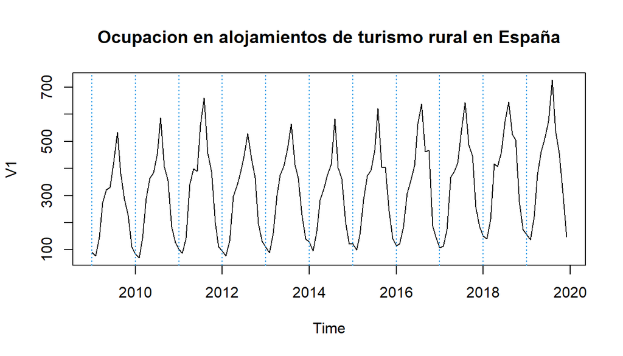

## Filtro lineal

Un cop es coneix el valor de tots els coeficients es grafica la tendència de la serie:

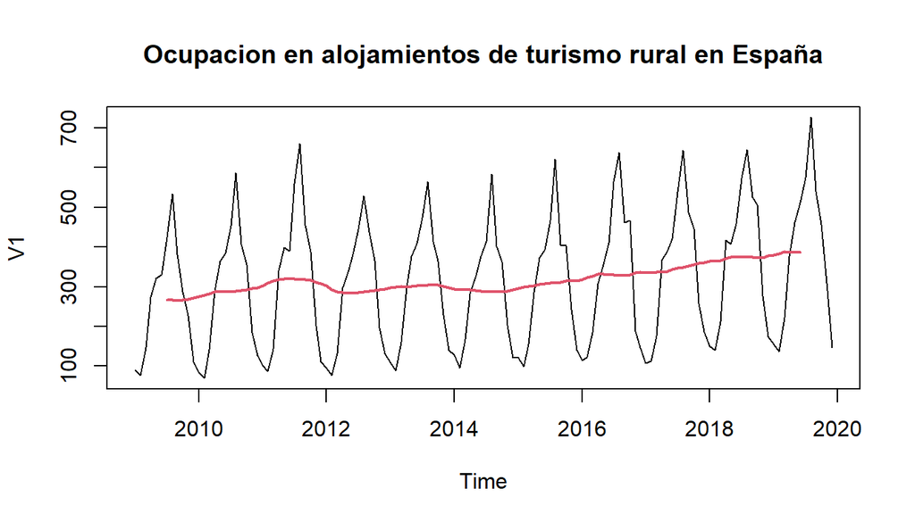

## Estimar la component de Estacionalitat (S)

Per estimar la component d’estacionalitat, els índexs estacionals, és molt important que aquests es calculin a partir de la sèrie sense tendència, ja que en cas contrari els resultats no serien els correctes.

Si es fa una representació visual del component d’estacionalitat s’obtenen els resultats següents:

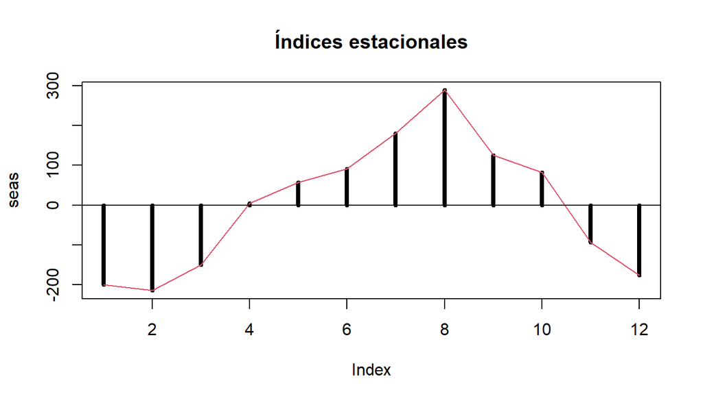

## Eliminem les components T i S de la Serie

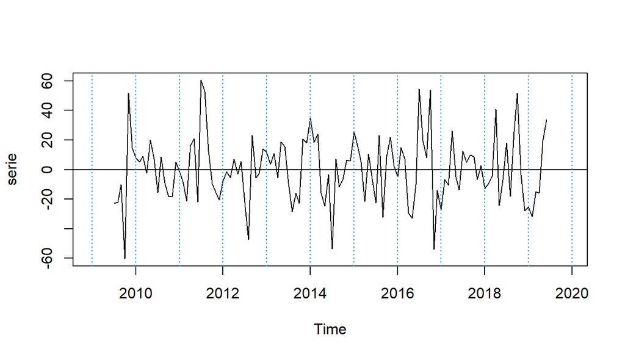

Efectivament, la distribució dels residus no segueix cap patró, aquests estan distribuïts de manera aleatòria al voltant del valor nul.

## Resum de les diferents seccions de la serie

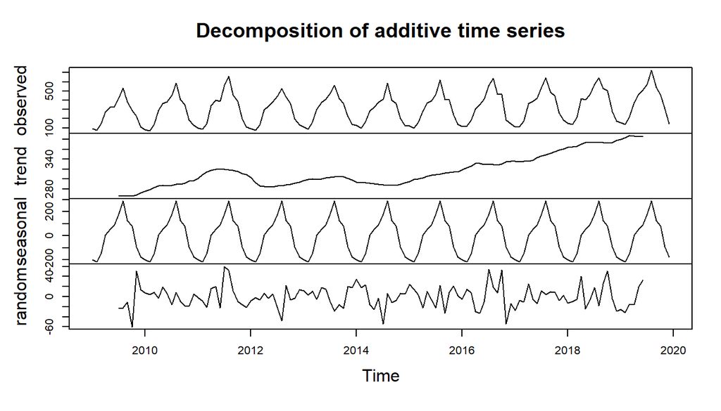

# Metodología de alisado

Hi ha 6 tipus de sèries temporals, els quals vénen definits de la següent manera:

$\text{ESQUEMA ADITIU}$

- **Serie temporal de tipus 1 - Sense tendència ni estacionalitat**
  - Equació per el suavitzat del nivell:
    $$l_t = \alpha X_t + (1 - \alpha)l_{t-1}$$
  - Valors iniciales: $\alpha, l_0$
  - Paràmetres a estimar: $\alpha$
- **Serie temporal de tipus 2 - amb tendència y sense estacionalitat**
  - Equació per el suavitzat del nivell:
    $$l_t = \alpha X_t + (1 - \alpha)(l_{t-1} + b_{t-1})$$
  - Equació per el suavitzat de la pendiente (tendència):
    $$b_t = \beta(l_t - l_{t-1}) + (1 - \beta)b_{t-1}$$
  - Valors iniciales: $\alpha, l_0, \beta, b_0$
  - Paràmetres a estimar: $\alpha, \beta$
- **Serie temporal de tipus 3 - sense tendència y amb estacionalitat aditiva**
  - Equació per el suavitzat del nivell:
    $$l_t = \alpha(X_t - S_{t-m})+(1 - \alpha)l_{t-1}$$
  - Equació per el suavitzat de la estacionalitat:
    $$S_t = \gamma(X_t - l_{t-1})+(1-\gamma)S_{t-m}$$
  - Valors iniciales: $\alpha, l_0, \gamma, S_{-m+1},...,S_0$
  - Paràmetres a estimar: $\alpha, \gamma$
- **Serie temporal de tipus 4 - amb tendència y amb estacionalitat aditiva**
  - Equació per el suavitzat del nivell:
    $$l_t = \alpha(X_t - S_{t-m})+(1-\alpha)(l_{t-1}+b_{t-1})$$
  - Equació per el suavitzat de la tendència:
    $$b_t = \beta(l_t - l_{t-1})+(1-\beta)b_{t-1}$$
  - Equació per el suavitzat de la estacionalitat:
    $$S_t = \gamma(X_t - l_{t-1} - b_{t-1}) + (1-\gamma)S_{t-m}$$
  - Valors iniciales: $\alpha, l_0, \beta, b_0, \gamma, S_{-m+1},...,S_0$
  - Paràmetres a estimar: $\alpha, \beta, \gamma$

$\text{ESQUEMA MULTIPLICATIU}$

- **Serie temporal de tipus 5 - sense tendència y amb estacionalitat multiplicativa**
  - Equació per el suavitzat del nivell:
    $$l_t = \alpha \frac{X_t}{S_{t-m}} + (1-\alpha)l_{t-1}$$
  - Equació per el suavitzat de la estacionalitat:
    $$S_t = \gamma \frac{X_t}{l_{t-1}}+(1-\gamma)S_{t-m}$$
  - Valors iniciales: $\alpha, l_0, \gamma, S_{-m+1},...,S_0$
  - Paràmetres a estimar: $\alpha, \gamma$
- **Serie temporal de tipus 6 - amb tendència y amb estacionalitat multiplicativa**
  - Equació per el suavitzat del nivell:
    $$l_t = \alpha \frac{X_t}{S_{t-m}} + (1-\alpha)(l_{t-1} + b_{t-1})$$
  - Equació per el suavitzat de la tendència:
    $$b_t = \beta(l_t - l_{t-1})+(1-\beta)b_{t-1}$$
  - Equació per el suavitzat de la estacionalitat:
    $$S_t = \gamma (\frac{X_t}{l_{t-1} + b_{t-1}})+(1-\gamma)S_{t-m}$$
  - Valors iniciales: $\alpha, l_0, \beta, \gamma, S_{-m+1},...,S_0$
  - Paràmetres a estimar: $\alpha, \beta, \gamma$

### **Asumir que la serie es tipus 3 (ANA) y aplicar filtro de Holt winters.**

```r
(hw<-HoltWinters(serie,alpha=NULL,beta=FALSE,gamma=NULL,seasonal="additive"))
```

```
## Holt-Winters exponential smoothing without trend and with additive seasonal component.
##
## Call:
## HoltWinters(x = serie, alpha = NULL, beta = FALSE, gamma = NULL,     seasonal = "additive")
##
## Smoothing parameters:
##  alpha: 0.2754205
##  beta : FALSE
##  gamma: 0.4229014
##
## Coefficients:
##           [,1]
## a    371.57526
## s1  -201.77052
## s2  -209.98348
## s3  -136.22091
## s4    26.33261
## s5    70.72667
## s6   111.33284
## s7   200.39675
## s8   313.10044
## s9   144.27722
## s10   95.72570
## s11  -90.87755
## s12 -198.65969
```

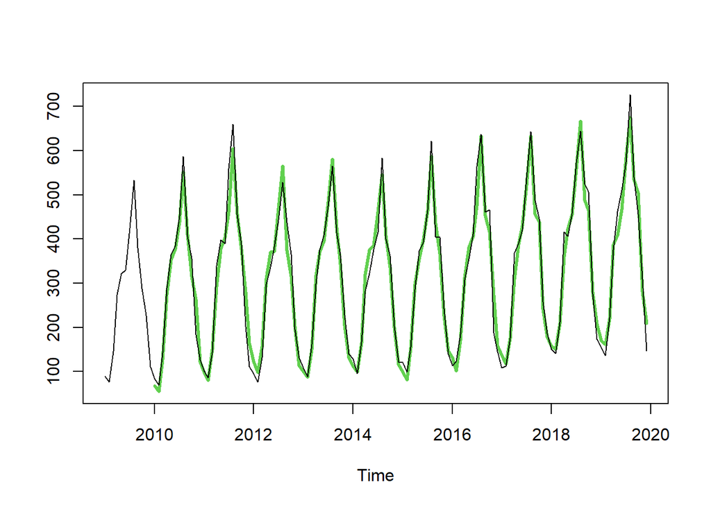

```r
ts.plot(fitted(hw)[,1],serie,col=c(3,1),lwd=c(3,1))
```

- Comentar Paràmetres.

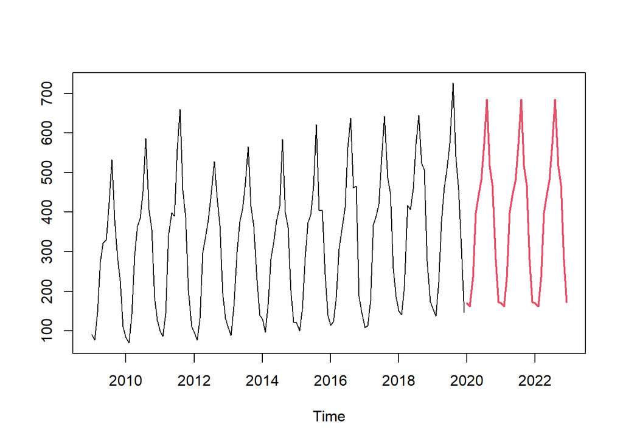

```r
pred=predict(hw,36)
ts.plot(serie,pred,col=c(1,2),lwd=c(1,2))
```

- Comentar predicción.

### **Asumir que la serie es tipus 4 (AAA) y aplicar filtro de Holt winters.**

```r
(hw<-HoltWinters(serie,alpha=NULL,beta=NULL,gamma=NULL,seasonal="additive"))
```

```
## Holt-Winters exponential smoothing with trend and additive seasonal component.
##
## Call:
## HoltWinters(x = serie, alpha = NULL, beta = NULL, gamma = NULL,     seasonal = "additive")
##
## Smoothing parameters:
##  alpha: 0.2842425
##  beta : 0.006078195
##  gamma: 0.426715
##
## Coefficients:
##            [,1]
## a    394.528137
## b      1.722665
## s1  -220.879542
## s2  -229.089273
## s3  -155.394886
## s4     6.965201
## s5    51.100838
## s6    91.487186
## s7   180.353264
## s8   292.863452
## s9   123.778934
## s10   75.011087
## s11 -111.758658
## s12 -219.596901
```

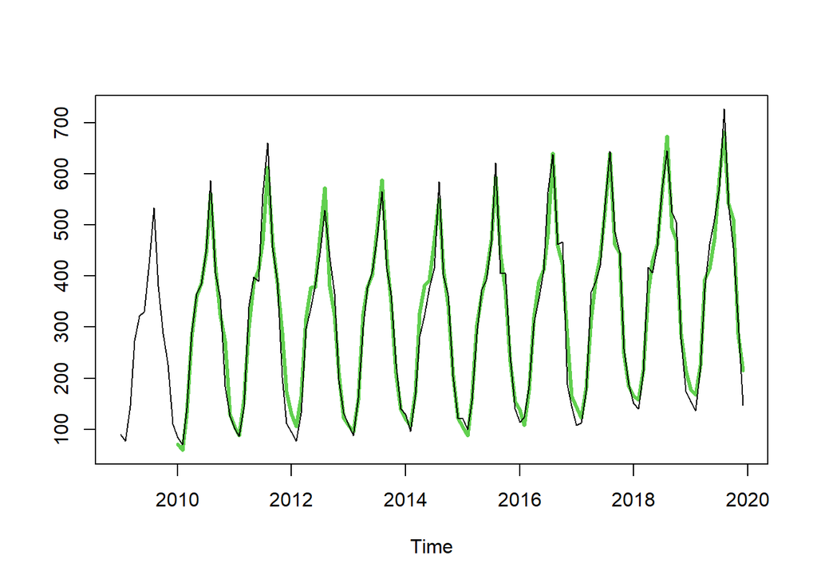

```r
ts.plot(fitted(hw)[,1],serie,col=c(3,1),lwd=c(3,1))
```

- Comentar Paràmetres.

#### Predicción a a ℎ pasos (out-of-sample).

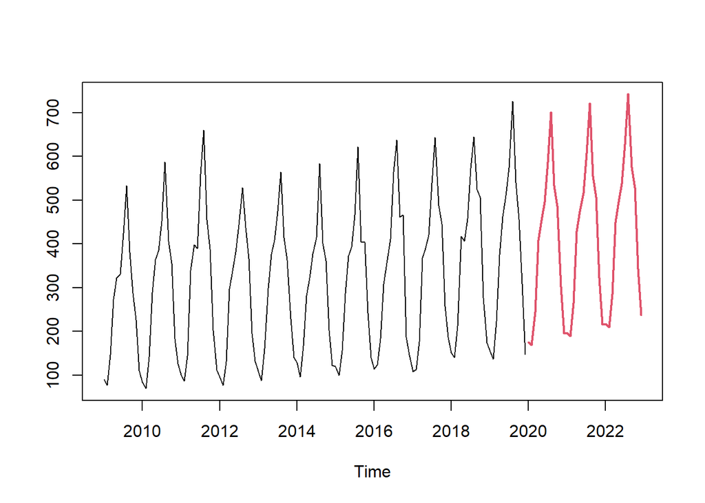

```r
pred=predict(hw,36)
ts.plot(serie,pred,col=c(1,2),lwd=c(1,2))
```

- Comentar predicción.

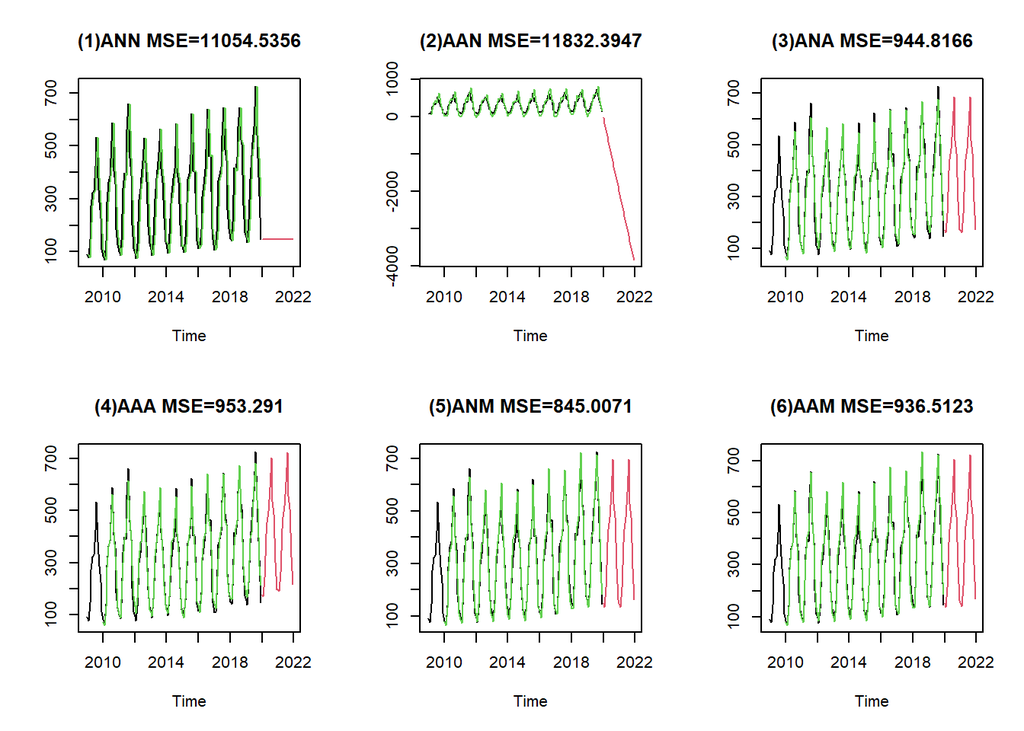

Veiem que el error quadratic mig dona més petit amb diferència en el cinquè tipus de serie (845’0071). seria el anm que correspondria a la no tendència i l’estacionalitat multiplicativa.

Per tant, es conclou tant de forma gràfica com numèrica que les dades sobre el nombre de milers de pasatjers mensuals en el port de Barceona pertanyen a una sèrie temporal de tipus 5.